# RE2 Approximate Matching: Propensity Scores

ECON 474 Econometrics of Policy Evaluation

**Overview**:

The exercise for today is to create a control group using approximate matching on observable variables. We can never match on unobserved variables, so it is up to us as the econometricians to consider and be transparent about the implicit biases these create. We are creating the control group by estimating **propensity scores of being treated** using data with observations that are treated and untreated via logistic regression.

We have a unique setting: we have data from the National Supported Work Demonstration (NSW) job-training program randomized experiment to produce and unbiased estimate of the average treatment effect (ATE). Once estimated, we are then going to suppose that we do not have a control group by creating one using the Current Population Survey (CPS).

**Caution**: I would only recommend creating a control group from an entirely different *data source* as a method of last resort. Using one data source for the treated group and another for the control group will likely (although not necessarily) introduce sample selection bias. The people participating in the NSW experiment are probably (again, not necessarily) different than those who are in the CPS.

Today, we are going to do the following:

1. Obtain the ATE using the randomized experiment data
2. Follow [Lalonde (1986)](https://www.jstor.org/stable/1806062#metadata_info_tab_contents) naïve methodology to
   1. produce a biased estimate of ATE using the entire CPS as a control group
   2. produce a balance table to show poor control group construction
3. Use approximate matching with propensity scores following [Dehejia and Wahbha (2002)](https://direct.mit.edu/rest/article/84/1/151/57311/Propensity-Score-Matching-Methods-for) to construct a better control group with the CPS

## 0.1 Preliminaries

We are going to need these packages for today:

- `haven`: allows for loading “foreign” data. We will need `read_dta()` to load Stata specific data
- `MatchIt`: for some assistance pscore matching with `matchit()`
- `tidyverse`: because how could you not?

If you haven’t installed them, do so in the console.

```r
library(haven) # install
library(MatchIt) # Install > No on compilation
library(tidyverse)
```

We are grabbing the data for today’s lecture from the GitHub created for the textbook. However, for some reason the function `download.file()` corrupts `.dta` files, so we are going to perform a work around.

```r
# path to our data
path_data = 'C:/Users/johnj/Dropbox/Julian/Academia/UIUC/Semester 12 Spring 2023/ECON474sp23/Data/'

# Loading to the data:
path_mixtape = 'https://raw.github.com/scunning1975/mixtape/master/'
file_nsw = 'nsw_mixtape.dta'
file_cps = 'cps_mixtape.dta'

# Loading in the National Supported Work
if(!file.exists(paste0(path_data, file_nsw))){
  print("Downloading...")
  nsw = read_dta(paste0(path_mixtape, file_nsw))
  write_dta(nsw, paste0(path_data, file_nsw))
}
nsw = read_dta(paste0(path_data, file_nsw))
head(nsw)
```

```
## # A tibble: 6 × 11
##   data_id         treat   age  educ black  hisp  marr nodeg…¹  re74  re75   re78
##   <chr>           <dbl> <dbl> <dbl> <dbl> <dbl> <dbl>   <dbl> <dbl> <dbl>  <dbl>
## 1 Dehejia-Wahba …     1    37    11     1     0     1       1     0     0  9930.
## 2 Dehejia-Wahba …     1    22     9     0     1     0       1     0     0  3596.
## 3 Dehejia-Wahba …     1    30    12     1     0     0       0     0     0 24909.
## 4 Dehejia-Wahba …     1    27    11     1     0     0       1     0     0  7506.
## 5 Dehejia-Wahba …     1    33     8     1     0     0       1     0     0   290.
## 6 Dehejia-Wahba …     1    22     9     1     0     0       1     0     0  4056.
## # … with abbreviated variable name ¹nodegree
```

```r
# Loading in the Current Population Survey data
if(!file.exists(paste0(path_data, file_cps))){
  cps = read_dta(paste0(path_mixtape, file_cps))
  write_dta(cps, paste0(path_data, file_cps))
}
cps = read_dta(paste0(path_data, file_cps))
head(cps)
```

```
## # A tibble: 6 × 11
##   data_id treat   age  educ black  hisp  marr nodegree   re74   re75   re78
##   <chr>   <dbl> <dbl> <dbl> <dbl> <dbl> <dbl>    <dbl>  <dbl>  <dbl>  <dbl>
## 1 CPS1        0    45    11     0     0     1        1 21517. 25244. 25565.
## 2 CPS1        0    21    14     0     0     0        0  3176.  5853. 13496.
## 3 CPS1        0    38    12     0     0     1        0 23039. 25131. 25565.
## 4 CPS1        0    48     6     0     0     1        1 24994. 25244. 25565.
## 5 CPS1        0    18     8     0     0     1        1  1669. 10728.  9861.
## 6 CPS1        0    22    11     0     0     1        1 16366. 18449. 25565.
```

Well would you look at that! The data are already cleaned for us **AND** they have the exact same variables! Life just became so easy!

For reference, the dictionary for the variables are:

- `data_id`: the source of the data
- `treat`: an indicator for received training treatment
- `educ`: years of schooling
- `black`: an indicator for being black
- `hisp`: an indicator for being Hispanic
- `nodegree`: an indicator for having no college degree
- `re74`, `re75`, `re78`: real earnings from 1974, 1975, and 1978 respectively

# 1 Unbiased ATE Benchamrk

Because the NSW was a randomized experiment, we can simply calculate the ATE using:

$$E[\delta] = E[Y^1 | D = 1] - E[Y^0 | D =
0] = E[Y^1] - E[Y^0]$$
or in our finite sample case:

$$\hat{\delta} =
\frac{1}{N^T}\sum_{treated} y_i - \frac{1}{N^C}\sum_{control}
y_i$$

```r
ate_exp =
  nsw %>%
  group_by(treat) %>%
  summarise(y = mean(re78)) %>%
  pivot_wider(values_from = y,
              names_from = treat,
              names_prefix = 'y_') %>%
  mutate(ate_exp = y_1 - y_0) %>%
  pull(ate_exp)

ate_exp
```

```
## [1] 1794.342
```

# 2 Lalonde (1986)

Before we can replicate the biased estimates, we need to construct the “full” data set that contains both NSW and CPS data. The whole point is to consider the case where we do not have a control group from a randomized experiment, so we are firstly going to `filter()` to only have observations such that `treat == 1` from the `nsw` data. We can then `bind_rows()` of `cps` because the variables have perfect naming overlap.

```r
df = nsw %>%
  filter(treat == 1) %>%
  bind_rows(cps)
```

## 2.1 Naïve ATE

Time for the biased ATE:

```r
ate_naive =
  df %>%
  group_by(treat) %>%
  summarise(y = mean(re78)) %>%
  pivot_wider(values_from = y,
              names_from = treat,
              names_prefix = 'y_') %>%
  mutate(ate_exp = y_1 - y_0) %>%
  pull(ate_exp)
ate_naive
```

```
## [1] -8497.516
```

Holy cow! The bias is so bad that we have a sign reversal! This is entirely due to selection bias because: $E[Y^1 | D = 0] \neq E[Y^0 | D = 0]$.

## 2.2 Balance Table

Before we create the balance table, we need to create two more variables that are used in Dehejia and Wahbha (2002): an indicator for being **not** employed (this is different than being unemployed) in 1974 and another for 1975. They do so by inferring non-employment from having zero earnings.

```r
df = df %>%
  mutate(not_emp_74 = (re74 == 0)*1,
         not_emp_75 = (re75 == 0)*1)
```

Now, time for the balance table.

```r
bal_tab = df %>%
  select(-data_id) %>%
  group_by(treat) %>%
  summarise(across(everything(), mean)) %>%
  pivot_longer(!treat,
               names_to = 'variable',
               values_to = 'D') %>%
  pivot_wider(values_from = D,
              names_from = treat,
              names_prefix = 'D_') %>%
  # reordering
  select(variable, D_1, D_0) %>%
  mutate(diff = D_1 - D_0)

# p-values
bal_tab$p_value = NA

for(v in names(df)[!names(df) %in% c('data_id', 'treat')]){
  bal_tab$p_value[bal_tab$variable == v] = t.test(df[[v]] ~ df[['treat']])$p.value
}

bal_tab
```

```
## # A tibble: 11 × 5
##    variable         D_1        D_0        diff   p_value
##    <chr>          <dbl>      <dbl>       <dbl>     <dbl>
##  1 age          25.8       33.2        -7.41   6.28e- 31
##  2 educ         10.3       12.0        -1.68   7.04e- 23
##  3 black         0.843      0.0735      0.770  4.02e- 70
##  4 hisp          0.0595     0.0720     -0.0126 4.75e-  1
##  5 marr          0.189      0.712      -0.523  8.72e- 43
##  6 nodegree      0.708      0.296       0.412  1.08e- 25
##  7 re74       2096.     14017.     -11921.     8.02e- 82
##  8 re75       1532.     13651.     -12119.     1.64e-120
##  9 re78       6349.     14847.      -8498.     8.78e- 33
## 10 not_emp_74    0.708      0.120       0.588  3.36e- 41
## 11 not_emp_75    0.6        0.109       0.491  1.51e- 29
```

We have a $\huge{\text{HUGE}}$ selection bias! All variables but one are statistically different between treatment and control groups!

# 3 Approximate Matching

Do not fret my fellow econometrician; all hope is not lost. It is time to reach into our econometric tool kit and pull out propensity score matching.

## 3.1 Obtaining Propensity Scores

Estimating propensity scores is super simple in `R`. All there is to do is estimate a regression, but specifically a logistic regression with a generalized linear model `glm()` specified to a logistic regression by setting the argument `family` equal to `binomial`.

Following Dehejia and Wahbha (2002), we will use the following regrssion:

$$\begin{align}
\text{log odds}\widehat{(D_i)} & = \beta_0 + \beta_1 age_i +
\beta_2 age^2_i + \beta_3 age_i^3 +\\
& \beta_4 educ_i + \beta_5 educ_i^2 + \beta_6 black_i + \beta_7
hisp_i + \\
& \beta_8 re74_i + \beta_{9} re75_i + \beta_{10} u74_i +
\beta_{11} u75_i +\\
& \beta_{12} educ_i*re74_i
\end{align}$$

Thankfully, we can take advantage of a few features of the `formula` objects to save us from needing to write out all of those variables.

```r
fit_pscore = glm(treat ~ poly(age, 3) + educ*re74 + I(educ^2) + re75 + black + hisp + not_emp_74 + not_emp_75,
                 data = df,
                 family = 'binomial')
summary(fit_pscore)
```

```
##
## Call:
## glm(formula = treat ~ poly(age, 3) + educ * re74 + I(educ^2) +
##     re75 + black + hisp + not_emp_74 + not_emp_75, family = "binomial",
##     data = df)
##
## Deviance Residuals:
##     Min       1Q   Median       3Q      Max
## -1.9628  -0.0446  -0.0155  -0.0053   3.8254
##
## Coefficients:
##                 Estimate Std. Error z value Pr(>|z|)
## (Intercept)   -9.234e+00  1.311e+00  -7.045 1.86e-12 ***
## poly(age, 3)1 -1.199e+02  2.268e+01  -5.285 1.25e-07 ***
## poly(age, 3)2 -8.386e+01  1.892e+01  -4.433 9.29e-06 ***
## poly(age, 3)3  7.522e+01  1.567e+01   4.800 1.58e-06 ***
## educ           1.067e+00  2.670e-01   3.998 6.39e-05 ***
## re74          -1.924e-04  1.158e-04  -1.661   0.0968 .
## I(educ^2)     -7.129e-02  1.405e-02  -5.072 3.93e-07 ***
## re75          -2.083e-04  3.710e-05  -5.614 1.97e-08 ***
## black          4.080e+00  2.636e-01  15.480  < 2e-16 ***
## hisp           1.761e+00  4.009e-01   4.393 1.12e-05 ***
## not_emp_74     1.808e+00  2.850e-01   6.344 2.24e-10 ***
## not_emp_75    -1.437e-03  2.510e-01  -0.006   0.9954
## educ:re74      1.936e-05  9.825e-06   1.971   0.0488 *
## ---
## Signif. codes:  0 '***' 0.001 '**' 0.01 '*' 0.05 '.' 0.1 ' ' 1
##
## (Dispersion parameter for binomial family taken to be 1)
##
##     Null deviance: 2022.14  on 16176  degrees of freedom
## Residual deviance:  857.64  on 16164  degrees of freedom
## AIC: 883.64
##
## Number of Fisher Scoring iterations: 10
```

Excellent! To obtain the propensity scores ($\widehat{p(x_i)}$), we just need to call the `fitted.value` from the fitted model. Let’s add the scores to our data frame.

```r
df = df %>%
  mutate(pscore = fit_pscore$fitted.values)
```

Here the propensity scores $p(x_i)$ are just a function of all of the 13 variables mentioned above. Recall that the propensity score is a sufficient statistic to condition on according the Propensity Score Theorem. We can therefore use the scores to visually examine treatment and control group balance.

To do so, we are going to create side-by-side histograms of the treatment and control group histograms in `ggplot2` . But first, let’s add one variable in advance to help with plotting labels. *Note: you can achieve the same result using features of* `ggplot2` *without creating a variable*.

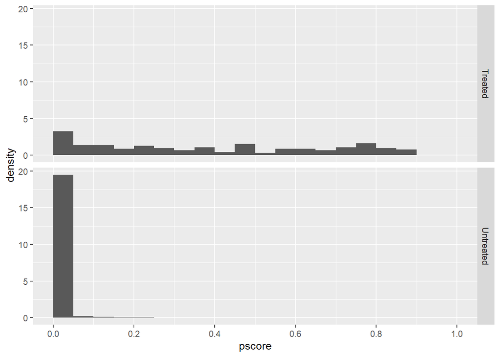

```r
df = df %>%
  mutate(Group = ifelse(treat == 1,
                        'Treated',
                        'Untreated'))

ggplot(df, aes(x = pscore)) +
  geom_histogram(aes(y = ..density..),
                 breaks = seq(0, 1, by = 0.05)) +
  facet_grid(rows = vars(Group)) +
  scale_x_continuous(breaks = seq(0, 1, by = 0.2))
```

Yeah, the overlap is not the best…

## 3.2 Propensity Score Matching

We will perform our approximate matching using the nearest neighbors method. That is, for each treated observation we will obtain $n$ control buddies. Here, we will use $n=5$ buddies.

We *could* match the nearest neighbors ourselves, but that sounds outrageously difficult. Let’s do ourselves a favor and take advantage of the `matchit()` function from the `MatchIt()` package. This will look very similar to the `glm()` specification above.

```r
fit_m = matchit(treat ~ poly(age, 3) + educ*re74 + I(educ^2) + re75 + black + hisp + not_emp_74 + not_emp_75,
                data = df,
                distance = 'logit',
                method = 'nearest',
                ratio = 5)

df_m = match.data(fit_m)
head(df_m)
```

```
## # A tibble: 6 × 18
##   data_id treat   age  educ black  hisp  marr nodeg…¹  re74  re75   re78 not_e…²
##   <chr>   <dbl> <dbl> <dbl> <dbl> <dbl> <dbl>   <dbl> <dbl> <dbl>  <dbl>   <dbl>
## 1 Deheji…     1    37    11     1     0     1       1     0     0  9930.       1
## 2 Deheji…     1    22     9     0     1     0       1     0     0  3596.       1
## 3 Deheji…     1    30    12     1     0     0       0     0     0 24909.       1
## 4 Deheji…     1    27    11     1     0     0       1     0     0  7506.       1
## 5 Deheji…     1    33     8     1     0     0       1     0     0   290.       1
## 6 Deheji…     1    22     9     1     0     0       1     0     0  4056.       1
## # … with 6 more variables: not_emp_75 <dbl>, pscore <dbl>, Group <chr>,
## #   distance <dbl>, weights <dbl>, subclass <fct>, and abbreviated variable
## #   names ¹nodegree, ²not_emp_74
```

I don’t know about you, but that seems pretty easy to me.

Now we come to one of the major concerns of propensity score matching: sample size.

```r
nrow(df)
```

```
## [1] 16177
```

```r
nrow(df_m)
```

```
## [1] 1110
```

Nonetheless, we can still produce an estimate of the ATE. However, we are going to need use a regression because of the covariate imbalance even though we have matched with propensity scores.

```r
lm(re78 ~ treat, data = df_m) %>% summary
```

```
##
## Call:
## lm(formula = re78 ~ treat, data = df_m)
##
## Residuals:
##    Min     1Q Median     3Q    Max
##  -6349  -6334  -2436   4571  53959
##
## Coefficients:
##             Estimate Std. Error t value Pr(>|t|)
## (Intercept)  6333.64     239.63  26.431   <2e-16 ***
## treat          15.51     586.97   0.026    0.979
## ---
## Signif. codes:  0 '***' 0.001 '**' 0.01 '*' 0.05 '.' 0.1 ' ' 1
##
## Residual standard error: 7288 on 1108 degrees of freedom
## Multiple R-squared:  6.3e-07,    Adjusted R-squared:  -0.0009019
## F-statistic: 0.0006981 on 1 and 1108 DF,  p-value: 0.9789
```

Now check this out:

```r
fit_nn = lm(re78 ~
              treat +
              poly(age, 3) + educ*re74 + I(educ^2) + re75 + black + hisp + not_emp_74 + not_emp_75,
                data = df_m)
summary(fit_nn)
```

```
##
## Call:
## lm(formula = re78 ~ treat + poly(age, 3) + educ * re74 + I(educ^2) +
##     re75 + black + hisp + not_emp_74 + not_emp_75, data = df_m)
##
## Residuals:
##    Min     1Q Median     3Q    Max
## -15618  -3861  -1838   3262  54207
##
## Coefficients:
##                 Estimate Std. Error t value Pr(>|t|)
## (Intercept)    5.898e+03  2.730e+03   2.160  0.03099 *
## treat          1.693e+03  5.746e+02   2.946  0.00328 **
## poly(age, 3)1 -1.975e+04  7.177e+03  -2.752  0.00602 **
## poly(age, 3)2 -1.497e+03  7.755e+03  -0.193  0.84695
## poly(age, 3)3 -1.043e+04  6.764e+03  -1.542  0.12336
## educ          -7.748e+02  5.440e+02  -1.424  0.15466
## re74           2.236e-01  2.302e-01   0.972  0.33148
## I(educ^2)      5.142e+01  2.864e+01   1.796  0.07285 .
## re75           4.199e-01  7.382e-02   5.688 1.65e-08 ***
## black          8.943e+01  5.984e+02   0.149  0.88124
## hisp           1.793e+03  7.155e+02   2.506  0.01236 *
## not_emp_74     4.062e+02  6.119e+02   0.664  0.50694
## not_emp_75    -1.067e+03  5.525e+02  -1.932  0.05366 .
## educ:re74      3.543e-03  1.907e-02   0.186  0.85261
## ---
## Signif. codes:  0 '***' 0.001 '**' 0.01 '*' 0.05 '.' 0.1 ' ' 1
##
## Residual standard error: 6437 on 1096 degrees of freedom
## Multiple R-squared:  0.2284, Adjusted R-squared:  0.2193
## F-statistic: 24.96 on 13 and 1096 DF,  p-value: < 2.2e-16
```

```r
ate_pscore5 = coef(fit_nn)[2]
ate_pscore5
```

```
##    treat
## 1692.862
```

## 3.3 Propensity Score Trimming

Much like a standard outlier observation, observations with extreme propensity scores can have leverage on estimates in finite sample coefficient estimation. The standard recommendation is to trim the propensity scores such that they are $\hat{p} \in [0.1, 0.9]$. How do our data look?

```r
df_m %>%
  group_by(Group) %>% # could use `treat` too
  summarise(less_0.1 = sum(pscore < 0.1)/n(),
            greater_0.9 = sum(pscore > 0.9)/n())
```

```
## # A tibble: 2 × 3
##   Group     less_0.1 greater_0.9
##   <chr>        <dbl>       <dbl>
## 1 Treated      0.232           0
## 2 Untreated    0.721           0
```

We have a large share of both treated and untreated observations with low propensity scores. They *might* have an affect on estimates. To find out, we are going to trim the data to be without the extreme propensity scores.

```r
df_m_trim = df_m %>% filter(pscore >= 0.1 & pscore <= 0.9)

lm(re78 ~ treat + poly(age, 3) + educ*re74 + I(educ^2) + re75 + black + hisp + not_emp_74 + not_emp_75,
   data = df_m_trim) %>%
  summary
```

```
##
## Call:
## lm(formula = re78 ~ treat + poly(age, 3) + educ * re74 + I(educ^2) +
##     re75 + black + hisp + not_emp_74 + not_emp_75, data = df_m_trim)
##
## Residuals:
##    Min     1Q Median     3Q    Max
## -10481  -4193  -1944   2740  53040
##
## Coefficients:
##                 Estimate Std. Error t value Pr(>|t|)
## (Intercept)    6.780e+03  5.783e+03   1.172   0.2418
## treat          1.630e+03  7.921e+02   2.058   0.0403 *
## poly(age, 3)1 -9.049e+03  7.297e+03  -1.240   0.2157
## poly(age, 3)2 -9.803e+03  8.422e+03  -1.164   0.2452
## poly(age, 3)3  2.960e+03  7.479e+03   0.396   0.6925
## educ          -1.109e+03  1.055e+03  -1.051   0.2939
## re74          -2.271e-01  6.092e-01  -0.373   0.7096
## I(educ^2)      7.801e+01  5.756e+01   1.355   0.1761
## re75           6.256e-01  2.410e-01   2.596   0.0098 **
## black         -4.171e+02  2.671e+03  -0.156   0.8760
## hisp          -1.505e+03  2.978e+03  -0.505   0.6135
## not_emp_74     8.769e+02  1.121e+03   0.782   0.4346
## not_emp_75    -7.851e+02  9.876e+02  -0.795   0.4272
## educ:re74      2.586e-02  5.441e-02   0.475   0.6349
## ---
## Signif. codes:  0 '***' 0.001 '**' 0.01 '*' 0.05 '.' 0.1 ' ' 1
##
## Residual standard error: 6699 on 386 degrees of freedom
## Multiple R-squared:  0.09418,    Adjusted R-squared:  0.06367
## F-statistic: 3.087 on 13 and 386 DF,  p-value: 0.0002217
```

Great news! The coefficient is effectively unchanged! However, it has become barely significant at the 95% confidence level. The answer to this should be immediately apparent from the very nature of trimming:

```r
nrow(df_m)
```

```
## [1] 1110
```

```r
nrow(df_m_trim)
```

```
## [1] 400
```

So, what do you do now that you have the untrimmed and trimmed estimates that produced the same estimate? In this particular case, I would present the results from the untrimmed results because it has more power (more observations) and mention that the trimmed estimates produce nearly identical point estimates.

# 4 Conclusion